# Motor Trend - Does automatic transmission improve miles per gallon performance?

Paolo Saracco

2024-05-10

# Executive summary

We examine the effect of the transmission type (manual vs automatic) on the miles per gallon (mpg) in the mtcars dataset using linear regression. In particular, we focus on the following questions:

- Is an automatic or manual transmission better for mpg?
- Can we quantify the mpg difference between automatic and manual transmissions?

### Packages

We will use the `dplyr` package for working with data frames and the `ggplot2` package for graphs.

```r
library(dplyr)
library(ggplot2)
```

# Data

The data set comes from the 1974 Motor Trend US magazine, and comprises fuel consumption and 10 aspects of automobile design and performance for 32 automobiles (1973–74 models).

```r
library(datasets)
data("mtcars")
```

# Exploratory data analysis

```r
str(mtcars)
```

```
## 'data.frame':    32 obs. of  11 variables:
##  $ mpg : num  21 21 22.8 21.4 18.7 18.1 14.3 24.4 22.8 19.2 ...
##  $ cyl : num  6 6 4 6 8 6 8 4 4 6 ...
##  $ disp: num  160 160 108 258 360 ...
##  $ hp  : num  110 110 93 110 175 105 245 62 95 123 ...
##  $ drat: num  3.9 3.9 3.85 3.08 3.15 2.76 3.21 3.69 3.92 3.92 ...
##  $ wt  : num  2.62 2.88 2.32 3.21 3.44 ...
##  $ qsec: num  16.5 17 18.6 19.4 17 ...
##  $ vs  : num  0 0 1 1 0 1 0 1 1 1 ...
##  $ am  : num  1 1 1 0 0 0 0 0 0 0 ...
##  $ gear: num  4 4 4 3 3 3 3 4 4 4 ...
##  $ carb: num  4 4 1 1 2 1 4 2 2 4 ...
```

```r
tail(mtcars)
```

```
##                 mpg cyl  disp  hp drat    wt qsec vs am gear carb
## Porsche 914-2  26.0   4 120.3  91 4.43 2.140 16.7  0  1    5    2
## Lotus Europa   30.4   4  95.1 113 3.77 1.513 16.9  1  1    5    2
## Ford Pantera L 15.8   8 351.0 264 4.22 3.170 14.5  0  1    5    4
## Ferrari Dino   19.7   6 145.0 175 3.62 2.770 15.5  0  1    5    6
## Maserati Bora  15.0   8 301.0 335 3.54 3.570 14.6  0  1    5    8
## Volvo 142E     21.4   4 121.0 109 4.11 2.780 18.6  1  1    4    2
```

```r
summary(mtcars)
```

```
##       mpg             cyl             disp             hp
##  Min.   :10.40   Min.   :4.000   Min.   : 71.1   Min.   : 52.0
##  1st Qu.:15.43   1st Qu.:4.000   1st Qu.:120.8   1st Qu.: 96.5
##  Median :19.20   Median :6.000   Median :196.3   Median :123.0
##  Mean   :20.09   Mean   :6.188   Mean   :230.7   Mean   :146.7
##  3rd Qu.:22.80   3rd Qu.:8.000   3rd Qu.:326.0   3rd Qu.:180.0
##  Max.   :33.90   Max.   :8.000   Max.   :472.0   Max.   :335.0
##       drat             wt             qsec             vs
##  Min.   :2.760   Min.   :1.513   Min.   :14.50   Min.   :0.0000
##  1st Qu.:3.080   1st Qu.:2.581   1st Qu.:16.89   1st Qu.:0.0000
##  Median :3.695   Median :3.325   Median :17.71   Median :0.0000
##  Mean   :3.597   Mean   :3.217   Mean   :17.85   Mean   :0.4375
##  3rd Qu.:3.920   3rd Qu.:3.610   3rd Qu.:18.90   3rd Qu.:1.0000
##  Max.   :4.930   Max.   :5.424   Max.   :22.90   Max.   :1.0000
##        am              gear            carb
##  Min.   :0.0000   Min.   :3.000   Min.   :1.000
##  1st Qu.:0.0000   1st Qu.:3.000   1st Qu.:2.000
##  Median :0.0000   Median :4.000   Median :2.000
##  Mean   :0.4062   Mean   :3.688   Mean   :2.812
##  3rd Qu.:1.0000   3rd Qu.:4.000   3rd Qu.:4.000
##  Max.   :1.0000   Max.   :5.000   Max.   :8.000
```

To begin with, it is useful to look at a plot of how the different mpg measures (25th, 50th, and 75th percentile of mpg) vary across the two categories.

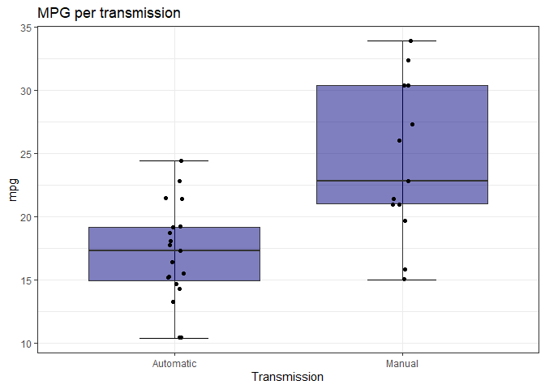

Figure 1: Box plot

It seems that manual transmission is better for mpg : cars with manual transmission covers more miles per gallon. To quantify this effect we perform a linear regression with `mpg` as outcome and the factor variable `am` as predictor, without intercept (which is the same as a T-test)

```r
naive_fit <- lm(mpg ~ as.factor(am)-1, data = mtcars)
```

|  | mean | std error | 95% conf int |
| --- | --- | --- | --- |
| automatic | 17.1474 | 1.1246 | [14.8506, 19.4441] |
| manual | 24.3923 | 1.3596 | [21.6157, 27.1689] |

However, we reasonably expect that other factors play a role. For example:

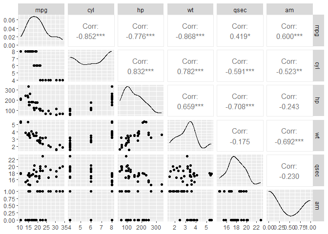

Figure 2: Pair plot

As we can see, `mpg` is also influenced by `cyl`, `hp`, `wt`, `qsec`, and not all of them are uncorrelated.

# Model selection

It may happen that the effect of transmission on miles per gallon is biased by the fact that we are not considering other factors. Therefore we start nesting models in order to see if adding regressors have a significant effect above and beyond the change in degrees of freedom.

```r
data <- mtcars %>%
        mutate(
                cyl = as.factor(cyl),
                vs = as.factor(vs),
                am = as.factor(am),
                gear = as.factor(gear),
                carb = as.factor(carb)
        )
```

Since it is clear that the weight of the car influences its miles per gallon, we start adding `wt` to our model and then we ask whether adding another variable has a significant effect, by relying on the ANOVA test.

```r
seek <- function(var, params = c()) {
        formula <- reformulate(c(params, var), response = 'mpg')
        fit_new <- lm(formula, data)
        cat("p-value for adding", var, "is", anova(fit, fit_new)[2,6], "\n")
}

fit <- lm(mpg ~ am + wt, data)
invisible(sapply(names(select(data, !c(mpg,am,wt))), seek, params = c('am','wt')))
```

```
## p-value for adding cyl is 0.003473216
## p-value for adding disp is 0.0678774
## p-value for adding hp is 0.0005464023
## p-value for adding drat is 0.2849371
## p-value for adding qsec is 0.0002161737
## p-value for adding vs is 0.008454158
## p-value for adding gear is 0.1200295
## p-value for adding carb is 0.2470563
```

```
##     qsec   hp
## wt -0.17 0.66
```

then we add `qsec` to our model and we ask ourselves the same question.

```r
fit <- lm(mpg ~ am + wt + qsec, data)
invisible(sapply(names(select(data, !c(mpg,am,wt,qsec))), seek, params = c('am','wt','qsec') ))
```

```
## p-value for adding cyl is 0.4582894
## p-value for adding disp is 0.4717085
## p-value for adding hp is 0.2230879
## p-value for adding drat is 0.6390028
## p-value for adding vs is 0.9931865
## p-value for adding gear is 0.9858944
## p-value for adding carb is 0.8960083
```

We conclude that no other variable has a significant effect, so we search for potential cross-effects:

| ANOVA w.r.t. adding | `am:wt` | `am:qsec` | `wt:qsec` |
| --- | --- | --- | --- |
| p-value | 0.0018086 | 0.0384079 | 0.2823973 |

We can fit our linear model with `mpg` as output and `am`, `wt`, `am:wt`, `qsec` as regressors and view the inference results:

```r
fit <- lm(mpg ~ am*wt + qsec, data)
summary(fit)
```

```
##
## Call:
## lm(formula = mpg ~ am * wt + qsec, data = data)
##
## Residuals:
##     Min      1Q  Median      3Q     Max
## -3.5076 -1.3801 -0.5588  1.0630  4.3684
##
## Coefficients:
##             Estimate Std. Error t value Pr(>|t|)
## (Intercept)    9.723      5.899   1.648 0.110893
## am1           14.079      3.435   4.099 0.000341 ***
## wt            -2.937      0.666  -4.409 0.000149 ***
## qsec           1.017      0.252   4.035 0.000403 ***
## am1:wt        -4.141      1.197  -3.460 0.001809 **
## ---
## Signif. codes:  0 '***' 0.001 '**' 0.01 '*' 0.05 '.' 0.1 ' ' 1
##
## Residual standard error: 2.084 on 27 degrees of freedom
## Multiple R-squared:  0.8959, Adjusted R-squared:  0.8804
## F-statistic: 58.06 on 4 and 27 DF,  p-value: 7.168e-13
```

|  | estimate | std error | 95% conf int |
| --- | --- | --- | --- |
| manual | 14.0794 | 3.4353 | [7.0309, 21.128] |

Moreover, we are satisfied because our model significantly explains about 90% of the variance (R-squared is 0.8959).

We can check if regression assumptions are met, namely the normality assumption for the residuals, with a Shapiro-Wilk test and diagnostic plotting:

```r
shapiro.test(fit$residuals)
```

```
##
##  Shapiro-Wilk normality test
##
## data:  fit$residuals
## W = 0.94444, p-value = 0.1001
```

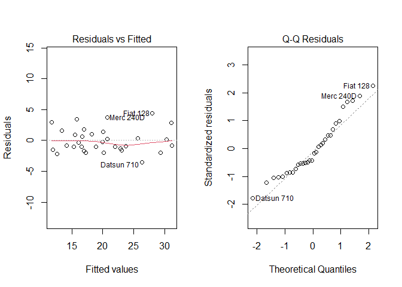

Figure 3: Diagnostic plotting

Normality assumptions don’t seem far off (approximately), and heteroskedasticity doesn’t seem to be an issue.

# Conclusions

However, the number of observations is relatively small, whence it is difficult to draw trustful conclusions. Figure 4 offers a glimpse of the problem. It is advisable to obtain a new and larger data set to challenge these results.

# Appendices

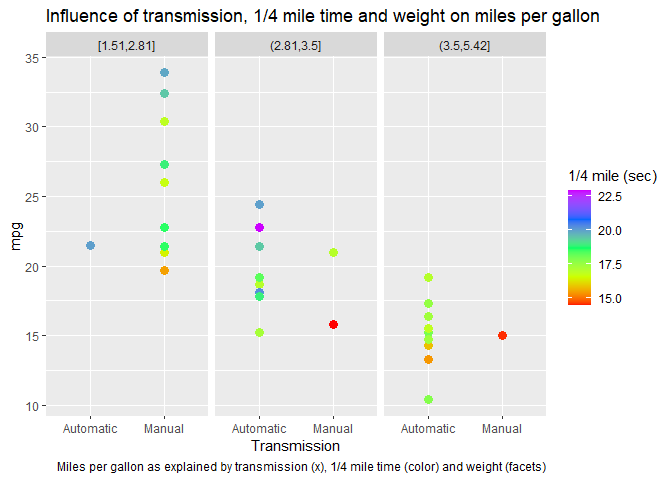

Figure 4: 4-dim scatterplot